# Imports

```python
# Suppress FutureWarning
import warnings
warnings.simplefilter(action='ignore', category=FutureWarning)

# Suppress CopyWarning
from pandas.core.common import SettingWithCopyWarning
warnings.simplefilter(action="ignore", category=SettingWithCopyWarning)

import pandas as pd
from pandas.plotting import scatter_matrix
import numpy as np
import seaborn as sns
import sklearn

# Set global seed for consistency
np.random.seed(42)

# Import support functions
from sklearn.model_selection import train_test_split
from sklearn.model_selection import cross_val_score
from sklearn.model_selection import KFold
from sklearn.pipeline import make_pipeline
from sklearn.preprocessing import StandardScaler
from sklearn.preprocessing import MinMaxScaler
from sklearn import metrics

# Import eval functions
from sklearn.metrics import mean_squared_error
from sklearn.metrics import mean_absolute_error
from sklearn.metrics import r2_score

# matplotlib defaults
%matplotlib inline
import matplotlib as mpl
import matplotlib.pyplot as plt
mpl.rc('axes', labelsize=14)
mpl.rc('xtick', labelsize=12)
mpl.rc('ytick', labelsize=12)

# Import models
from sklearn import linear_model
from sklearn.ensemble import RandomForestRegressor
from sklearn.linear_model import LogisticRegression

# Print multiple outputs per cell
# from IPython.core.interactiveshell import InteractiveShell
# InteractiveShell.ast_node_interactivity = 'all'
```

# Supporting Functions

```python
def score_model(model, x_train, y_train, x_test, y_test):
        ## Score for training data set
        y_pred_train = model.predict(x_train)

        print(f"#### {type(model).__name__} - Training dataset scores ####")
        try:
            print(f"The intercept for model is {model.intercept_:.4f}")
        except:
            pass
        print(f'Mean Absolute Error: {mean_absolute_error(y_train, y_pred_train):.6f}')
        print(f'Mean Squared Error: {mean_squared_error(y_train, y_pred_train):.6f}')
        print(f'Root Mean Squared Error: {np.sqrt(mean_squared_error(y_train, y_pred_train)):.6f}')
        print(f'R2 score: {model.score(x_train, y_train):.6f}')
        print()

        ## Score for testing data set
        y_pred_test = model.predict(x_test)

        print(f"#### {type(model).__name__} - Testing dataset scores ####")
        try:
            print(f"The intercept for model is {model.intercept_:.4f}")
        except:
            pass
        print(f'Mean Absolute Error: {mean_absolute_error(y_test, y_pred_test):.6f}')
        print(f'Mean Squared Error: {mean_squared_error(y_test, y_pred_test):.6f}')
        print(f'Root Mean Squared Error: {np.sqrt(mean_squared_error(y_test, y_pred_test)):.6f}')
        print(f'R2 score: {model.score(x_test, y_test):.6f}')
```

# Data Load and Preparation

```python
# Load dataset
# I am using the wine dataset. More info about the columns can be found on Kaggle:
# https://www.kaggle.com/uciml/red-wine-quality-cortez-et-al-2009
#
# The Kaggle set also references the original work, a copy is found here:
# https://www.sciencedirect.com/science/article/abs/pii/S0167923609001377?via%3Dihub

data = pd.read_csv("wine.csv", encoding= 'unicode_escape')
```

```python
data.info()
```

```
<class 'pandas.core.frame.DataFrame'>
RangeIndex: 1599 entries, 0 to 1598
Data columns (total 12 columns):
 #   Column                Non-Null Count  Dtype
---  ------                --------------  -----
 0   fixed acidity         1599 non-null   float64
 1   volatile acidity      1599 non-null   float64
 2   citric acid           1599 non-null   float64
 3   residual sugar        1599 non-null   float64
 4   chlorides             1599 non-null   float64
 5   free sulfur dioxide   1599 non-null   float64
 6   total sulfur dioxide  1599 non-null   float64
 7   density               1599 non-null   float64
 8   pH                    1599 non-null   float64
 9   sulphates             1599 non-null   float64
 10  alcohol               1599 non-null   float64
 11  quality               1599 non-null   int64
dtypes: float64(11), int64(1)
memory usage: 150.0 KB
```

```python
data.sample(5)
```

|  | fixed acidity | volatile acidity | citric acid | residual sugar | chlorides | free sulfur dioxide | total sulfur dioxide | density | pH | sulphates | alcohol | quality |
| --- | --- | --- | --- | --- | --- | --- | --- | --- | --- | --- | --- | --- |
| 803 | 7.7 | 0.56 | 0.08 | 2.50 | 0.114 | 14.0 | 46.0 | 0.9971 | 3.24 | 0.66 | 9.6 | 6 |
| 124 | 7.8 | 0.50 | 0.17 | 1.60 | 0.082 | 21.0 | 102.0 | 0.9960 | 3.39 | 0.48 | 9.5 | 5 |
| 350 | 10.7 | 0.67 | 0.22 | 2.70 | 0.107 | 17.0 | 34.0 | 1.0004 | 3.28 | 0.98 | 9.9 | 6 |
| 682 | 8.5 | 0.46 | 0.31 | 2.25 | 0.078 | 32.0 | 58.0 | 0.9980 | 3.33 | 0.54 | 9.8 | 5 |
| 1326 | 6.7 | 0.46 | 0.24 | 1.70 | 0.077 | 18.0 | 34.0 | 0.9948 | 3.39 | 0.60 | 10.6 | 6 |

```python
data.describe()
```

|  | fixed acidity | volatile acidity | citric acid | residual sugar | chlorides | free sulfur dioxide | total sulfur dioxide | density | pH | sulphates | alcohol | quality |
| --- | --- | --- | --- | --- | --- | --- | --- | --- | --- | --- | --- | --- |
| count | 1599.000000 | 1599.000000 | 1599.000000 | 1599.000000 | 1599.000000 | 1599.000000 | 1599.000000 | 1599.000000 | 1599.000000 | 1599.000000 | 1599.000000 | 1599.000000 |
| mean | 8.319637 | 0.527821 | 0.270976 | 2.538806 | 0.087467 | 15.874922 | 46.467792 | 0.996747 | 3.311113 | 0.658149 | 10.422983 | 5.636023 |
| std | 1.741096 | 0.179060 | 0.194801 | 1.409928 | 0.047065 | 10.460157 | 32.895324 | 0.001887 | 0.154386 | 0.169507 | 1.065668 | 0.807569 |
| min | 4.600000 | 0.120000 | 0.000000 | 0.900000 | 0.012000 | 1.000000 | 6.000000 | 0.990070 | 2.740000 | 0.330000 | 8.400000 | 3.000000 |
| 25% | 7.100000 | 0.390000 | 0.090000 | 1.900000 | 0.070000 | 7.000000 | 22.000000 | 0.995600 | 3.210000 | 0.550000 | 9.500000 | 5.000000 |
| 50% | 7.900000 | 0.520000 | 0.260000 | 2.200000 | 0.079000 | 14.000000 | 38.000000 | 0.996750 | 3.310000 | 0.620000 | 10.200000 | 6.000000 |
| 75% | 9.200000 | 0.640000 | 0.420000 | 2.600000 | 0.090000 | 21.000000 | 62.000000 | 0.997835 | 3.400000 | 0.730000 | 11.100000 | 6.000000 |
| max | 15.900000 | 1.580000 | 1.000000 | 15.500000 | 0.611000 | 72.000000 | 289.000000 | 1.003690 | 4.010000 | 2.000000 | 14.900000 | 8.000000 |

```python
# Check for null values
data.isna().sum()
```

```
fixed acidity           0
volatile acidity        0
citric acid             0
residual sugar          0
chlorides               0
free sulfur dioxide     0
total sulfur dioxide    0
density                 0
pH                      0
sulphates               0
alcohol                 0
quality                 0
dtype: int64
```

This dataset is complete with 1599 non-null entries. I will be using it to see how well we can predict the amount of `residual sugar` in the wine, using the other columns as features. This is purely anecdotal, but for myself and most of my friends, how sweet a wine is determines whether we will like it much or not. This is pretty hard to gauge unless we taste the wine, or unless it is labelled `sec`, `demi-sec`, `dry`, `brut`, etc. The former requires money and potentially getting wine we don't find tasty. Labels are rare from my experience as well, most bottles simply state the type of wine.

I am hoping that there is a correlation between the features and sugar content, especially `alcohol` v. `residual sugar`. Alcohol content is always on the bottle, and if it can help predict residual sugar then we have a much better basis for choosing wine to try. We can also look at `acidity`, most stores we buy from mention this too, and it can usually be found on Google.

[figure not shown]

Image from https://winefolly.com/deep-dive/what-is-residual-sugar-in-wine/, which also has an explanation for residual sugar.

# EDA

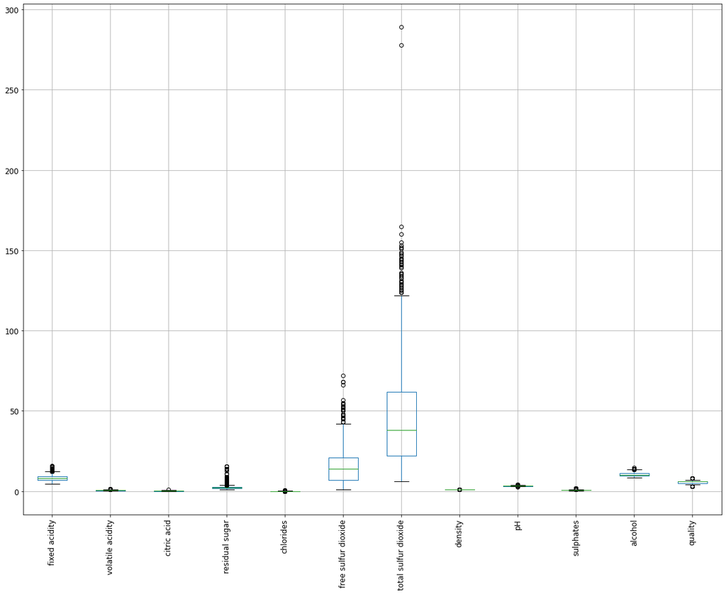

```python
# No null values is great, next we check for outliers visually.

data.boxplot(figsize=(20,15))
plt.xticks(rotation = 90);
```

Everything looks okay on first glance. We should remake these boxplots on separate `y-axes` however, as the ranges are too different to accurately show everything. We can also inspect the two potential outliers for `total sulfur dioxide`.

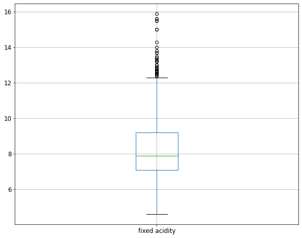

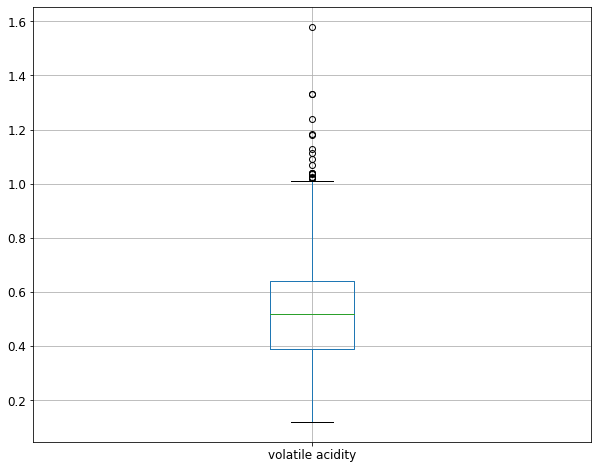

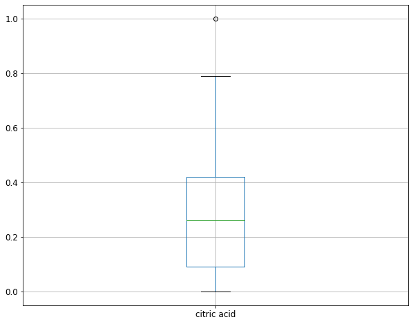

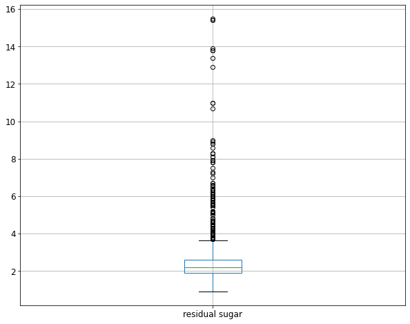

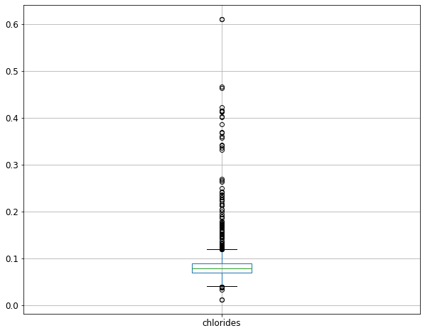

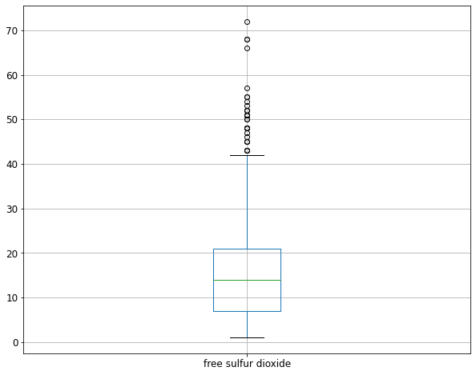

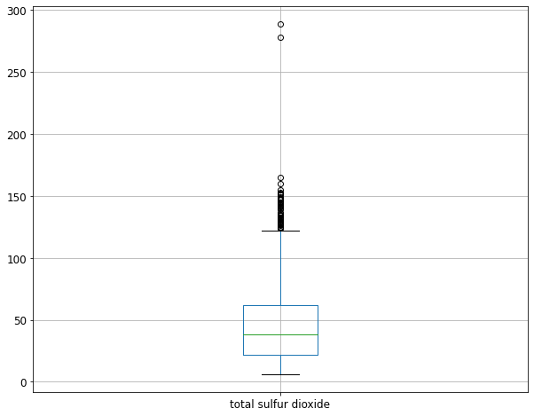

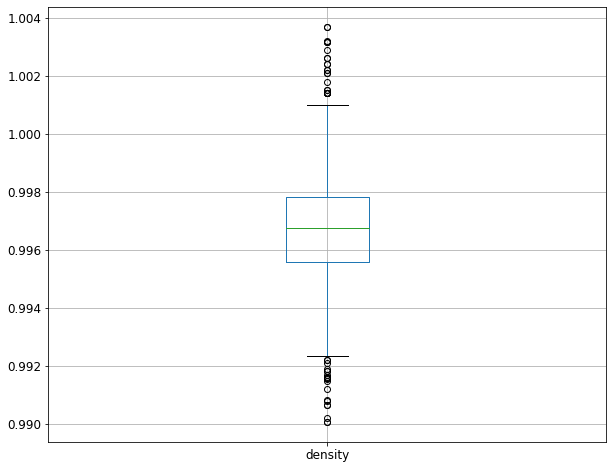

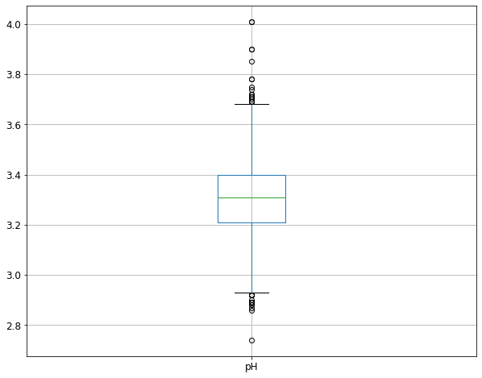

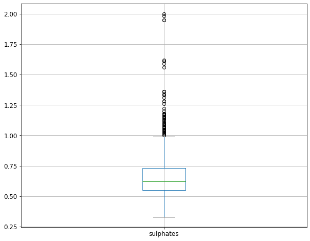

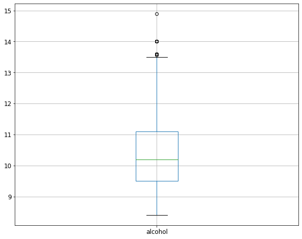

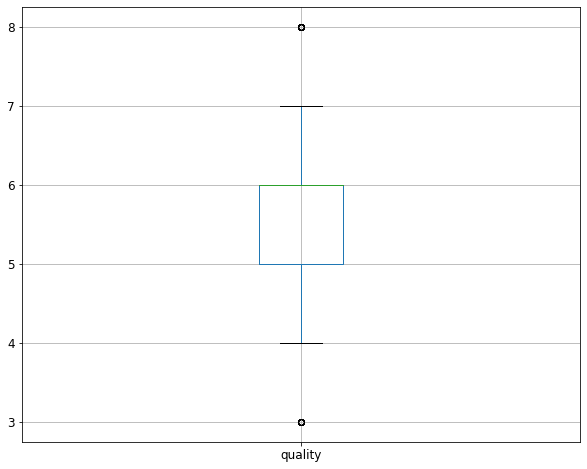

```python
# Creating individual boxplots

for column in data:
    plt.figure(figsize=(10,8))
    data.boxplot([column])
```

These are much better. We can still see the two outliers for `total sulfur dioxide`. Inspecting further, we see everything else looks OK. However, the maximum legal limit in the USA seems to be 200ppm at first glance, so we can just drop these values.

```python
data.loc[data['total sulfur dioxide'] > 200]
```

|  | fixed acidity | volatile acidity | citric acid | residual sugar | chlorides | free sulfur dioxide | total sulfur dioxide | density | pH | sulphates | alcohol | quality |
| --- | --- | --- | --- | --- | --- | --- | --- | --- | --- | --- | --- | --- |
| 1079 | 7.9 | 0.3 | 0.68 | 8.3 | 0.05 | 37.5 | 278.0 | 0.99316 | 3.01 | 0.51 | 12.3 | 7 |
| 1081 | 7.9 | 0.3 | 0.68 | 8.3 | 0.05 | 37.5 | 289.0 | 0.99316 | 3.01 | 0.51 | 12.3 | 7 |

```python
data = data.loc[data['total sulfur dioxide'] < 200]
```

Next, I will create some histograms to start analyzing any visual trends in the data.

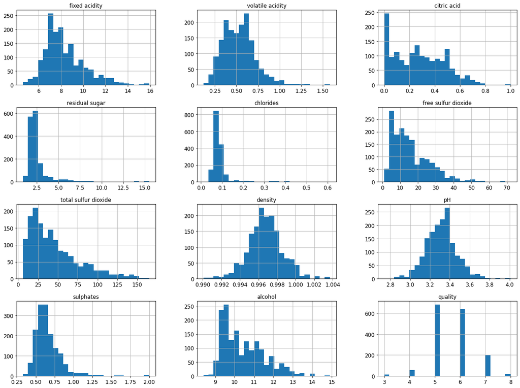

```python
data.hist(bins=25, figsize=(20,15))
plt.show()
```

Next, I am interested to see the scatter and correlation matrices for this dataset. This will clue us into the important features we'll focus on later.

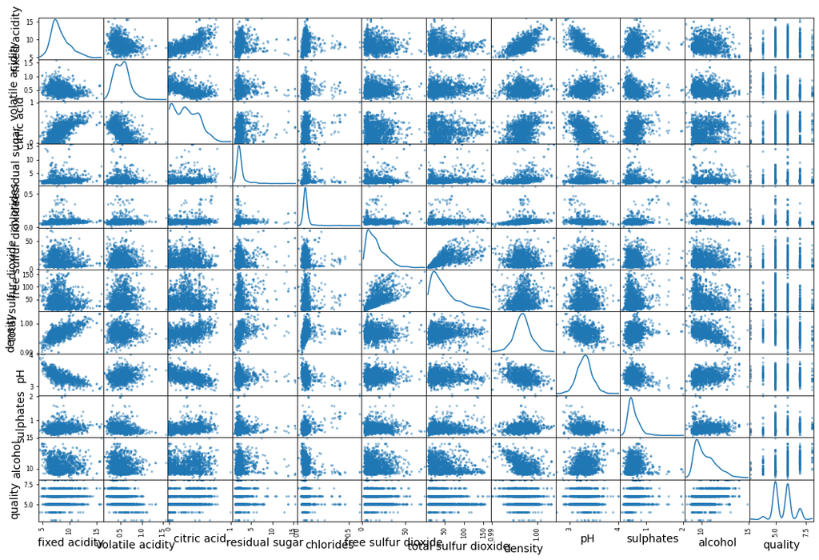

```python
scatter_matrix(data, figsize=(18, 12), diagonal='kde');
```

Some of these plots reveal trends, we can check them more closely. I'll hold the `residual sugar` constant on the y-axis, and see if there are any trends by iterating through the other columns.

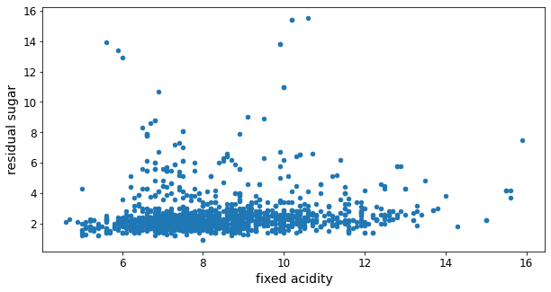

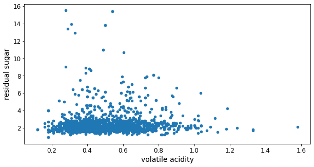

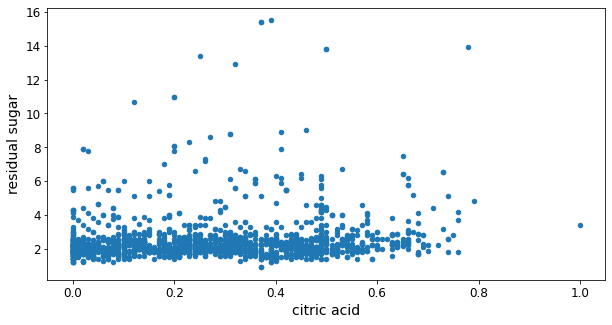

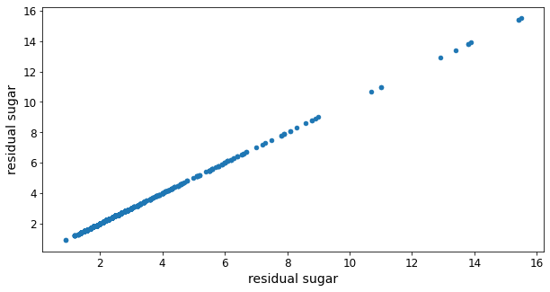

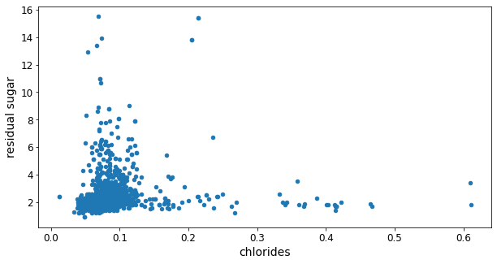

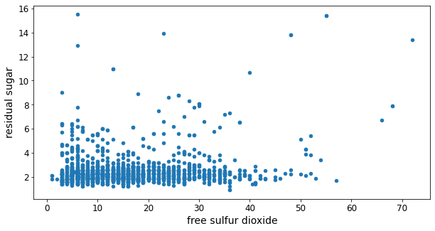

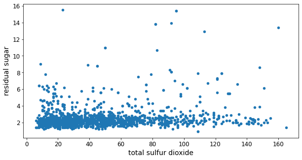

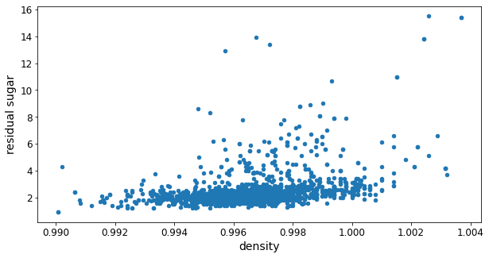

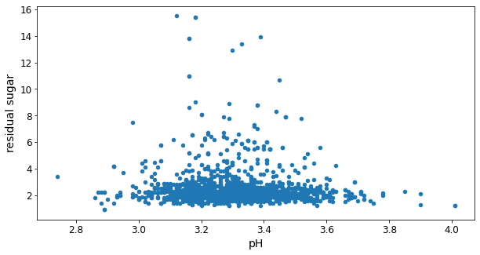

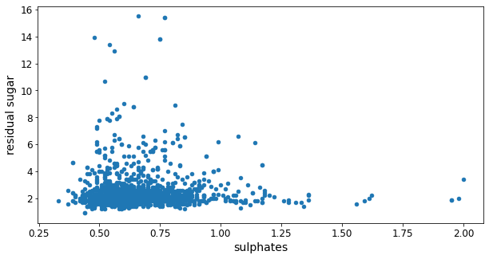

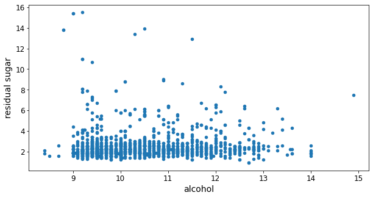

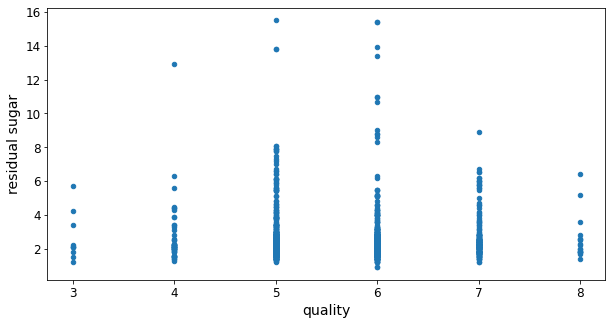

```python
for column in data:
    data.plot(kind="scatter", x=column, y="residual sugar", figsize=(10,5));
```

Nothing too obvious, checking correlation matrix...

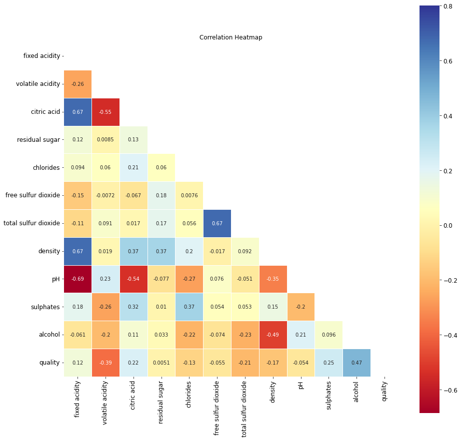

```python
cm = data.corr()
mask= np.triu(np.ones_like(cm, dtype=bool))

f, ax = plt.subplots(figsize=(15, 15))
sns.heatmap(cm, vmax=.8, square=True, mask = mask, annot=True, cmap='RdYlBu', linewidths=.9 )
plt.title(f'Correlation Heatmap')
```

# Model Training - Regression

Looking at the `residual sugar` column, nothing looks too strongly correlated. Nevertheless, we will train our models and see how accurate of a prediction we can make.

```python
# Splitting into features and label

X = data.drop("residual sugar", axis=1).copy()
y = data["residual sugar"].copy()
```

```python
# Creating a train/test split. I will reserve 20% of the data for testing.

x_train, x_test, y_train, y_test = train_test_split(X, y, test_size=0.20, random_state=42)

model = linear_model.Lasso(alpha=0.1)
model.fit(x_train, y_train)

score_model(model, x_train, y_train, x_test, y_test)
```

```
#### Lasso - Training dataset scores ####
The intercept for model is 1.2435
Mean Absolute Error: 0.760619
Mean Squared Error: 1.966402
Root Mean Squared Error: 1.402284
R2 score: 0.058361

#### Lasso - Testing dataset scores ####
The intercept for model is 1.2435
Mean Absolute Error: 0.685623
Mean Squared Error: 1.311199
Root Mean Squared Error: 1.145076
R2 score: 0.046882
```

Lasso Regression results are pretty abysmal. We won't be predicting anything based on these results.

```python
x_train, x_test, y_train, y_test = train_test_split(X, y, test_size=0.20, random_state=42)

model = RandomForestRegressor(max_depth=10, random_state=0, n_jobs=-1, n_estimators=500)
model.fit(x_train, y_train)

score_model(model, x_train, y_train, x_test, y_test)
```

```
#### RandomForestRegressor - Training dataset scores ####
Mean Absolute Error: 0.318146
Mean Squared Error: 0.237636
Root Mean Squared Error: 0.487479
R2 score: 0.886205

#### RandomForestRegressor - Testing dataset scores ####
Mean Absolute Error: 0.482863
Mean Squared Error: 0.714764
Root Mean Squared Error: 0.845437
R2 score: 0.480434
```

The more powerful random forest regressor does much better in the training, but still has only about 50% accuracy with the test set. Perhaps it is a better idea to assert we will like wines with `residual sugar` greater than a certain threshold. We can then feed these features into a classifier, which will take into account how all the variables affect this preference. This may reveal other hidden trends I didn't consider previously.

# Model Training - Classification

```python
# Because this dataset is from a limited selection and type of wine, the residual sugar
# doesn't go higher than 15 g/L. Most dessert wines are around 45 g/L, while I personally
# consider >30 g/L sweet. For this case study, I will set values above 4 g/L as "tasty".

data['tasty'] = np.where(data['residual sugar'] >= 4, 1, 0)
```

```python
# I will be using the LogisticRegressor. We need to normalize the data for this to work.
#
# Splitting into features and label again, this time dropping residual sugar to not
# make the algorithm hyper-fixate on that variable (as there is technically a trivial
# correlation between 'taste' and 'residual sugar' when the latter is > 4 g/L.

X = data.drop("tasty", axis=1).copy()
X = X.drop("residual sugar", axis=1)
X = StandardScaler().fit_transform(X)

y = data["tasty"].copy()
```

```python
x_train, x_test, y_train, y_test = train_test_split(X, y, test_size=0.20, random_state=42)

model = LogisticRegression(random_state=42)
model.fit(x_train, y_train)

score_model(model, x_train, y_train, x_test, y_test)
```

```
#### LogisticRegression - Training dataset scores ####
Mean Absolute Error: 0.066562
Mean Squared Error: 0.066562
Root Mean Squared Error: 0.257997
R2 score: 0.933438

#### LogisticRegression - Testing dataset scores ####
Mean Absolute Error: 0.046875
Mean Squared Error: 0.046875
Root Mean Squared Error: 0.216506
R2 score: 0.953125
```

Let's create a confusion matrix and see where the model is making mistakes.

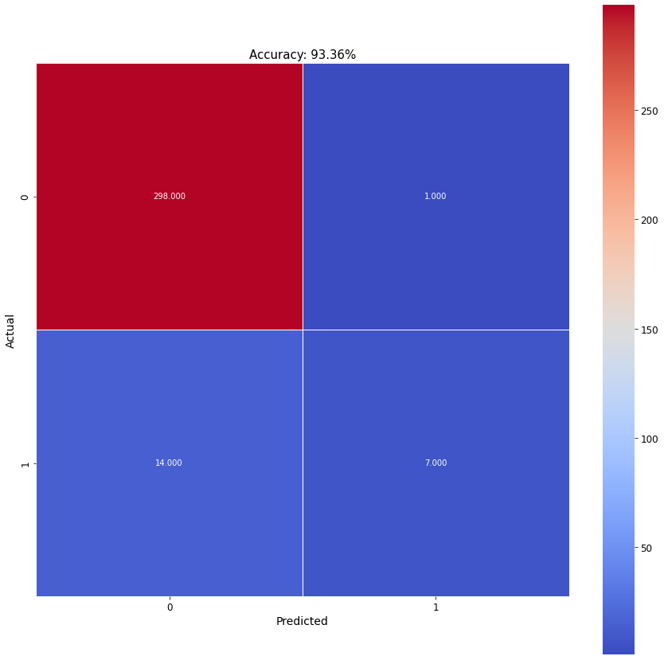

```python
# Creating a CV scoring to get a more representative accuracy score
fold = KFold(n_splits=10, random_state=1, shuffle=True)
scores = cross_val_score(model, X, y, scoring='accuracy', cv=fold, n_jobs=-1)

cm = metrics.confusion_matrix(y_test, model.predict(x_test))

plt.figure(figsize=(15,15))
sns.heatmap(cm, annot=True, fmt=".3f", linewidths=.5, square = True, cmap='coolwarm');
plt.ylabel('Actual');
plt.xlabel('Predicted');
title = f'Accuracy: {np.mean(scores)*100:.2f}%'
plt.title(title, size = 15);
```

The model is mostly making false negative errors - saying I might not like a wine, but in actuality there's a high chance I would. Because there is so much wine out there to try I'm actually OK with this. In this case I prefer to miss a wine I might like since there are other channels where I might find out about it. I would not want to get a wine and be excited about it, only to find it unpleasant.

# Conclusion

My main requirement is the sugar content; I am open to try the various other combinations of features and check what I might enjoy. As long as the sweetness is there, I can minimize the effects of the other predictors on my palate. The results are more valuable that I originally thought! This would allow me to broaden my tastes in a much more structured manner than just buying random bottles of wine.

# Further Improvements

The dataset is limited as discussed above, and also missing some features I think would be helpful in classification. Below I outline some improvements to the data I think would help.

- Include `wine_color` as a feature, determining if it is `red`, `white`, etc.
- Include more types of wine; `dessert`, `champagne`, `rosé`.
- Include wines from regions other than Portugal.
- Include more data points!